# Untitled

David Selby

7/9/2019

# Required Packages

```r
require( dplyr )
require( pander )
require( stringr )
require( hunspell )
```

#Load Data

```r
d2 <- readRDS( "Data/cleaned-titles.rds")
```

## Title Catagories

Shows the sorting of Standardized and Cleaned into titles into Catagories in the following steps:

1. Individuals are sorted to Catagories based on if they have one the 1000 most common titles.
2. The most common words or phrases associated with the catagories are used to sort remaining individuals into catagories (where they exist)
3. Catagorized Titles are used to create meta-titles (C-Suite, Management, Board, ect)

### Catagories

| Variable Name | Category Name |
| --- | --- |
| CEO | Chief Executive |
| CFO | Financial |
| Treasurer | Treasurer |
| DEP.CEO | Deputy Chief Executive |
| SEC | Secretary |
| COO | Operations |
| TRUST | Trustee/Board |
| HUM.RES | Human Resources |
| DEP.HEAD | Department Head |
| MAN Generic | Management |
| DEV | Development |
| TECH | Technology/IT |
| COMM | Communications |
| OTHER | Other Category |
| PROJECT | Project Manager |
| LEGAL | Legal |
| FACILITIES | Facilities |
| ADMIN.SUP | Administrative Support |
| MED.MAN | Medical Management |
| HEALTH.HUM | Health and Human Services |
| TRAIN | Training/Education |
| ACADEMIC.MAN | Academic Manager |
| PROFESIONAL | Professional |
| OTHER.PROF | Other Professional |
| ACADEMIC.PROF | Academic Professional |
| MED.PROF | Medical Professional |

### Form 990 Title Instructions

**Titles**

- Current officers, directors, and trustees ( no minimum compensation threshold ).
- Current key employees ( over $150,000 of reportable compensation ).
- Current five highest compensated employees other than officers, directors, trustees, or listed key employees ( over $100,000 of reportable compensation ).
- Former officers, key employees, and highest compensated employees ( over $100,000 of reportable compensation, with special rules for former highest compensated employees ).
- Former directors and trustees ( over $10,000 of reportable compensation in the capacity as a former director or trustee ).

**Director or Trustee**

A “director or trustee” is a member of the organization’s governing body, but only if the member has voting rights. A director or trustee that served at any time during the organization’s tax year is deemed a current director or trustee. Members of advisory boards that don’t exercise any governance authority over the organization aren’t considered directors or trustees.

An “institutional trustee” is a trustee that isn’t an individual or natural person but an organization. For instance, a bank or trust company serving as the trustee of a trust is an institutional trustee.

**Officer**

An officer is a person elected or appointed to manage the organization’s daily operations. An officer that served at any time during the organization’s tax year is deemed a current officer. The officers of an organization are determined by reference to its organizing document, bylaws, or resolutions of its governing body, or as otherwise designated consistent with state law, but, at a minimum, include those officers required by applicable state law. Officers can include a president, vice-president, secretary, treasurer and, in some cases, a Board Chair. In addition, for purposes of Form 990, including Part VII, Section A, and Schedule J ( Form 990 ), treat as an officer the following persons, regardless of their titles.

1. *Top management official*. The person who has ultimate responsibility for implementing the decisions of the governing body or for supervising the management, administration, or operation of the organization; for example, the organization’s president, CEO, or executive director.
2. *Top financial official*. The person who has ultimate responsibility for managing the organization’s finances; for example, the organization’s treasurer or chief financial officer.

If ultimate responsibility resides with two or more individuals ( for example, co-presidents or co-treasurers ), who can exercise such responsibility in concert or individually, then treat all such individuals as officers.

**Key Employees**

Key employee. For purposes of Form 990, a current key employee is an employee of the organization ( other than an officer, director, or trustee ) who meets all three of the following tests, applied in the following order:

1. $150,000 Test: Receives reportable compensation from the organization and all related organizations in excess of $150,000 for the calendar year ending with or within the organization’s tax year.
2. Responsibility Test: At any time during the calendar year ending with or within the organization’s tax year:
1. Has responsibilities, powers, or influence over the organization as a whole that is similar to those of officers, directors, or trustees;
2. Manages a discrete segment or activity of the organization that represents 10% or more of the activities, assets, income, or expenses of the organization, as compared to the organization as a whole; or
3. Has or shares authority to control or determine 10% or more of the organization’s capital expenditures, operating budget, or compensation for employees.
3. Top 20 Test: Is one of the 20 employees other than officers, directors, and trustees who satisfy the $150,000 Test and Responsibility Test with the highest reportable compensation from the organization and related organizations for the calendar year ending with or within the organization’s tax year.

If the organization has more than 20 individuals who meet the $150,000 Test and Responsibility Test, report as key employees only the 20 individuals that have the highest reportable compensation from the organization and related organizations. Note that any others, up to five, might be reportable as current highest compensated employees, with over $100,000 in reportable compensation. Use the calendar year ending with or within the organization’s tax year for determining the organization’s current key employees.

An individual that isn’t an employee of the organization ( or of a disregarded entity of the organization ) is nonetheless treated as a key employee if he or she serves as an officer or director of a disregarded entity of the organization and otherwise meets the standards of a key employee set forth above. See Disregarded Entities, later, for treatment of certain employees of a disregarded entity as a key employee of the organization.

If an employee is a key employee of the organization for only a portion of the year, that person’s entire compensation for the calendar year ending with or within the organization’s tax year, from both the filing organization and related organizations,should be reported in Part VII, Section A.

Management companies and similar entities that are independent contractors should not be reported as key employees. The organization’s top management official and top financial official are deemed officers rather than key employees.

In the examples set forth below, assume the individual involved is an employee that satisfies the $150,000 Test and Top 20 Test and isn’t an officer, director, or trustee.\

**Example 1.** T is a large section 501( c )( 3 ) university. L is the dean of the law school of T, which generates more than 10% of the revenue of T, including contributions from alumni and foundations. Although L does not have ultimate responsibility for managing the university as a whole, L meets the Responsibility Test and is reportable as a key employee of T.

**Example 2.** S chairs a small academic department in the College of Arts and Sciences of the same university, T, described above. As department chair, S supervises faculty in the department, approves the course curriculum, and oversees the operating budget for the department. The department represents less than 10% of the university’s activities, assets, income, expenses, capital expenditures, operating budget, and employee compensation. Under these facts and circumstances, S does not meet the Responsibility Test and isn’t a key employee of T.

**Example 3.** U is a large acute-care section 501( c )( 3 ) hospital. U employs X as a radiologist. X gives instructions to staff for the radiology work X conducts, but X does not supervise other U employees, manage the radiology department, or have or share authority to control or determine 10% or more of U’s capital expenditures, operating budget, or employee compensation. Under these facts and circumstances, X does not meet the Responsibility Test and isn’t a key employee of U. \

**Example 4.** W is a cardiologist and head of the cardiology department of the same hospital U described above. The cardiology department is a major source of patients admitted to U and consequently represents more than 10% of U’s income, as compared to U as a whole. As department head, W manages the cardiology department. Under these facts and circumstances, W meets the Responsibility Test and is a key employee of U. \

### Load Categorized Titles

```r
Title.Categorized <- load("Data/Title-List.Rdata")
All.Titles %>% names()
```

```
##  [1] "CEO"                "CFO"                "Treasurer"
##  [4] "DEP.CEO"            "SEC"                "COO"
##  [7] "TRUST"              "COMM"               "HUM.RES"
## [10] "DEP.HEAD"           "MAN"                "TECH"
## [13] "DEV"                "OTHER"              "PROJECT"
## [16] "LEGAL"              "FACILITIES"         "ADMIN.SUP"
## [19] "MED.MAN"            "HEALTH.HUM"         "TRAIN"
## [22] "ACADEMIC.MAN"       "PROFESIONAL"        "OTHER.PROF"
## [25] "ACADEMIC.PROF"      "MED.PROF"           "CEO.Clear"
## [28] "CFO.Clear"          "Treasurer.Clear"    "DEP.CEO.Clear"
## [31] "SEC.Clear"          "COO.Clear"          "TRUST.Clear"
## [34] "HUM.RES.Clear"      "COMM.Clear"         "MAN.Clear"
## [37] "TECH.Clear"         "DEV.Clear"          "CEO.Board"
## [40] "CEO.Prob"           "CFO.Prob"           "Treasurer.Prob"
## [43] "DEP.CEO.Prob"       "SEC.Prob"           "COO.Prob"
## [46] "TRUST.Prob"         "HUM.RES.Prob"       "MAN.Prob"
## [49] "DEV.Prob"           "CEO.SCHOOL"         "CEO.Prob.Other"
## [52] "TRUST.Prob.BOARD"   "TRUST.Prob.DEP.CEO" "TRUST.Prob.MAN"
## [55] "TRUST.Prob.OTHER"   "SCHOOL.HEAD"
```

Creates new Title Categories - These are NOT mutually exclusive.

```r
d3<-d2


d2$CEO           <- 0
d2$CFO           <- 0
d2$Treasurer     <- 0
d2$DEP.CEO       <- 0
d2$SEC           <- 0
d2$COO           <- 0
d2$TRUST         <- 0
d2$HUM.RES       <- 0
d2$DEP.HEAD      <- 0
d2$MAN           <- 0
d2$DEV           <- 0
d2$TECH          <- 0
d2$COMM          <- 0
d2$OTHER         <- 0
d2$PROJECT       <- 0
d2$LEGAL         <- 0
d2$FACILITIES    <- 0
d2$ADMIN.SUP     <- 0
d2$MED.MAN       <- 0
d2$HEALTH.HUM    <- 0
d2$TRAIN         <- 0
d2$ACADEMIC.MAN  <- 0
d2$PROFESIONAL   <- 0
d2$OTHER.PROF    <- 0
d2$ACADEMIC.PROF <- 0
d2$MED.PROF      <- 0

# d2[ !(d2$TitleTxt2 %in% All.TITLES.VEC) ] %>% nrow


# d2$CFO        [ !(d2$TitleTxt2 %in% All.TITLES.VEC) ] <- NA
# d2$Treasure   [ !(d2$TitleTxt2 %in% All.TITLES.VEC) ] <- NA
# d2$DEP.CEO    [ !(d2$TitleTxt2 %in% All.TITLES.VEC) ] <- NA
# d2$SEC        [ !(d2$TitleTxt2 %in% All.TITLES.VEC) ] <- NA
# d2$COO        [ !(d2$TitleTxt2 %in% All.TITLES.VEC) ] <- NA
# d2$TRUST      [ !(d2$TitleTxt2 %in% All.TITLES.VEC) ] <- NA
# d2$HUM.RES    [ !(d2$TitleTxt2 %in% All.TITLES.VEC) ] <- NA
# d2$DEP.HEAD   [ !(d2$TitleTxt2 %in% All.TITLES.VEC) ] <- NA
# d2$MAN        [ !(d2$TitleTxt2 %in% All.TITLES.VEC) ] <- NA
# d2$DEV        [ !(d2$TitleTxt2 %in% All.TITLES.VEC) ] <- NA
# d2$OTHER      [ !(d2$TitleTxt2 %in% All.TITLES.VEC) ] <- NA
```

### CEO

First, assign individuals to CEO catagory if they had a title that appeared in the 1000 most common titles that we coded to CEO.

```r
d2$CEO.Prob <- 0

d2$CEO[ d2$TitleTxt2 %in% All.Titles$CEO.Clear] <- 1

d2$CEO.Prob[ d2$TitleTxt2 %in% All.Titles$CEO.Prob] <- 1

# Test <-  d2 %>% filter ( CEO.Prob == 1 & TrustOrDir == 1 & Officer == 0)
# Test$TitleTxt2 %>% table( ) %>% sort( decreasing=T ) %>% as.data.frame( )
# TRUSTEE not CEO

d2$CEO   [ d2$CEO.Prob == 1 & d2$TrustOrDir == 1 & d2$Officer == 0]   <- 0
d2$TRUST [ d2$CEO.Prob == 1 & d2$TrustOrDir == 1 & d2$Officer == 0]   <- 1

# Test <- d2 %>% filter ( CEO.Prob == 1 & TrustOrDir == 0 & Officer == 1)
# Test$TitleTxt2 %>% table( ) %>% sort( decreasing=T ) %>% as.data.frame( )

# CEO Not Trustee
```

| TrustOrDir | Officer | KeyEmpl | HighComp | Meaning |
| --- | --- | --- | --- | --- |
| 1 | 0 | 0 | 0 | Board Probably not CEO |
| 0 | 1 | 0 | 0 | CEO |
| 1 | 1 | 0 | 0 | CEO |
| 0 | 0 | 1 | 0 | Management |
| 0 | 0 | 0 | 1 | Other |

```r
d2$CEO   [ d2$CEO.Prob == 1 & d2$TrustOrDir == 0 & d2$Officer == 1]   <- 1
d2$CEO[ d2$CEO.Prob == 1 & d2$TrustOrDir == 1 & d2$Officer == 1] <- 1
d2$TRUST[ d2$CEO.Prob == 1 & d2$TrustOrDir == 1 & d2$Officer == 1] <- 1
d2$TRUST[ d2$TitleTxt2 %in% All.Titles$CEO.Board] <- 1
d2$CEO [ d2$TitleTxt2 %in% All.Titles$CEO.Board] <- 1
d2$MAN [ d2$CEO.Prob == 1 & d2$TrustOrDir == 0 & d2$Officer == 0 & d2$KeyEmpl == 1] <- 1
d2$MAN [ d2$CEO.Prob == 1 & d2$TrustOrDir == 0 & d2$Officer == 0 & d2$HighComp == 1] <- 1
```

Next we want to assign individuals to the CEO catagory if they had one of the most common phrases associated with that title

```r
d2$CEO [ grepl( " CHIEF EXECUTIVE OFFICER ", d2$TitleTxt2) ] <- 1
d2$CEO [ grepl( " EXECUTIVE DIRECTOR ", d2$TitleTxt2) ] <- 1
d2$CEO [ grepl( " ASSISTANT EXECUTIVE DIRECTOR ", d2$TitleTxt2) ] <- 0



d2$TitleTxt2[ d2$CEO == 1 ] %>% table() %>% sort( decreasing=T ) %>% as.data.frame( ) %>% head( 20 ) %>% pander
```

| . | Freq |
| --- | --- |
| EXECUTIVE DIRECTOR | 157043 |
| PRESIDENT | 43051 |
| PRESIDENT CEO | 26303 |
| CEO | 21076 |
| CHIEF EXECUTIVE OFFICER | 7007 |
| HEAD SCHOOL | 3588 |
| PRINCIPAL | 3256 |
| PRESIDENT DIRECTOR | 2116 |
| CEO PRESIDENT | 1856 |
| FORMER EXECUTIVE DIRECTOR | 1793 |
| PRESIDENT EXECUTIVE DIRECTOR | 1520 |
| EXECUTIVE DIRECTOR CEO | 1315 |
| ASSOCIATE EXECUTIVE DIRECTOR | 1312 |
| HEADMASTER | 1241 |
| PRESIDENT CE | 1008 |
| INTERIM EXECUTIVE DIRECTOR | 978 |
| CO EXECUTIVE DIRECTOR | 827 |
| EXECUTIVE DIRECTOR SECRETARY | 790 |
| PRESIDENT TREASURER | 739 |
| SUPERINTENDENT | 664 |

### HEAD OF SCHOOL

[output not shown]

```r
d2$TRUST [d2$TitleTxt2 %in% All.Titles$SCHOOL.HEAD & d2$TrustOrDir == 1] <- 1
d2$CEO [d2$TitleTxt2 %in% All.Titles$SCHOOL.HEAD & d2$Officer == 1] <- 1
d2$MAN [d2$TitleTxt2 %in% All.Titles$SCHOOL.HEAD & d2$Officer == 0 & d2$TrustOrDir == 0 & d2$KeyEmpl == 1 ] <- 1
d2$OTHER [d2$TitleTxt2 %in% All.Titles$SCHOOL.HEAD & d2$Officer == 0 & d2$TrustOrDir == 0 & d2$KeyEmpl == 0 ] <- 1
```

### CFO

| TrustOrDir | Officer | KeyEmpl | HighComp | Meaning |
| --- | --- | --- | --- | --- |
| 1 | 0 | 0 | 0 | Board Probably not CFO? |
| 0 | 1 | 0 | 0 | CFO |
| 1 | 1 | 0 | 0 | CFO |

```r
d2$CFO.Prob <- 0

d2$CFO[ d2$TitleTxt2 %in% All.Titles$CFO.Clear] <- 1
d2$CFO.Prob[ d2$TitleTxt2 %in% All.Titles$CFO.Prob] <- 1

d2$CFO   [ d2$CFO.Prob == 1 & d2$TrustOrDir == 1]   <- 0
d2$TRUST [ d2$CFO.Prob == 1 & d2$Officer == 1   ]   <- 1
d2$CFO   [ d2$CFO.Prob == 1 & d2$KeyEmpl == 1]      <- 1
d2$CFO   [ d2$CFO.Prob == 1 & d2$HighComp == 1]     <- 1
d2$CFO   [ grepl( " CFO ", d2$TitleTxt2) ]          <- 1
d2$CFO   [ grepl( " CHIEF FINANCIAL OFFICER ", d2$TitleTxt2) ]          <- 1
d2$CFO   [ grepl( " FINANCE ", d2$TitleTxt2) ]          <- 1

d2$TRUST[ d2$CFO.Prob == 1 & d2$TrustOrDir == 1 & d2$Officer == 1] <- 1

titles <- d2$TitleTxt2[ d2$CFO == 1]


table( titles ) %>% sort( decreasing=T ) %>% as.data.frame( ) %>% head( 20 ) %>% pander
```

| titles | Freq |
| --- | --- |
| CFO | 21462 |
| CHIEF FINANCIAL OFFICER | 11058 |
| DIRECTOR FINANCE | 5802 |
| FINANCE DIRECTOR | 4269 |
| VICE PRESIDENT FINANCE | 3751 |
| VICE PRESIDENT CFO | 1818 |
| VICE PRESIDENT FINANCE ADMINISTRATION | 1210 |
| SENIOR VICE PRESIDENT CFO | 1107 |
| VICE PRESIDENT FINANCE CFO | 975 |
| CFO TREASURER | 833 |
| DIRECTOR FINANCE ADMINISTRATION | 829 |
| EXECUTIVE VICE PRESIDENT CFO | 773 |
| TREASURER CFO | 749 |
| DIRECTOR FINANCE OPERATIONS | 728 |
| FINANCE MANAGER | 591 |
| FISCAL DIRECTOR | 530 |
| FORMER CFO | 472 |
| FISCAL OFFICER | 448 |
| CFO COO | 430 |
| FINANCIAL DIRECTOR | 406 |

### Treasurer

```r
d2$Treasurer  [ d2$TitleTxt2 %in% All.Titles$Treasurer] <- 1
d2$Treasurer  [ grepl( " TREASURER ", d2$TitleTxt2) ]   <- 1


titles <- d2$TitleTxt2[ d2$Treasurer == 1]
table( titles ) %>% sort( decreasing=T ) %>% as.data.frame( ) %>% head( 20 ) %>% pander
```

| titles | Freq |
| --- | --- |
| TREASURER | 5720 |
| SECRETARY TREASURER | 2201 |
| ASSISTANT SECRETARY TREASURER | 1051 |
| ASSISTANT TREASURER | 1038 |
| CFO TREASURER | 833 |
| TREASURER CFO | 749 |
| PRESIDENT TREASURER | 739 |
| VICE PRESIDENT TREASURER | 455 |
| VICE PRESIDENT FINANCE TREASURER | 282 |
| TREASURER SECRETARY | 220 |
| EXECUTIVE DIRECTOR TREASURER | 200 |
| ASSISTANT TREASURER CFO | 167 |
| CFO ASSISTANT TREASURER | 158 |
| TREASURER DIRECTOR | 158 |
| ASSISTANT SECRETARY ASSISTANT TREASURER | 142 |
| SENIOR VICE PRESIDENT CFO TREASURER | 131 |
| FORMER ASSISTANT SECRETARY TREASURER | 129 |
| TREASURER VICE PRESIDENT FINANCE | 121 |
| SENIOR VICE PRESIDENT TREASURER | 120 |
| SECRETARY TREASURER CFO | 117 |

### Deputy CEO

```r
d2$DEP.CEO[ d2$TitleTxt2 %in% All.Titles$DEP.CEO ] <- 1

d2$DEP.CEO[ d2$TitleTxt2 %in% All.Titles$DEP.CEO.Prob & d2$Officer == 1 ] <- 1

#d2[ d2$TitleTxt2 %in% All.Titles$DEP.CEO.Prob, ]

d2$MAN [ d2$TitleTxt2 %in% All.Titles$DEP.CEO.Prob  & d2$Officer == 0 & (d2$KeyEmpl == 1 | d2$HighComp == 1 ) ] <- 1

titles <- d2$TitleTxt2[ d2$DEP.CEO == 1]
table( titles ) %>% sort( decreasing=T ) %>% as.data.frame( ) %>% head( 20 ) %>% pander
```

| titles | Freq |
| --- | --- |
| DEPUTY DIRECTOR | 1919 |
| ASSOCIATE EXECUTIVE DIRECTOR | 1312 |
| ASSISTANT EXECUTIVE DIRECTOR | 923 |
| DEPUTY EXECUTIVE DIRECTOR | 657 |
| ASSISTANT HEAD SCHOOL | 489 |
| ASSOCIATE HEAD SCHOOL | 209 |
| ASSISTANT HEADMASTER | 127 |
| DEPUTY CEO | 89 |
| EXECUTIVE VICE PRESIDENT PROVOST | 73 |
| CFO SECRETARY TREASURER | 62 |
| ASSISTANT CHIEF | 54 |
| DEPUTY EXECUTIVE | 54 |

### Secretary

```r
d2$SEC[ d2$TitleTxt2 %in%  All.Titles$SEC] <- 1
d2$SEC [ grepl( " SECRETARY ", d2$TitleTxt2) ] <- 1
d2$SEC [ grepl( " SEC ", d2$TitleTxt2) ] <- 1

titles <- d2$TitleTxt2[ d2$SEC == 1]
table( titles ) %>% sort( decreasing=T ) %>% as.data.frame( ) %>% head( 20 ) %>% pander
```

| titles | Freq |
| --- | --- |
| SECRETARY | 8351 |
| ASSISTANT SECRETARY | 2787 |
| SECRETARY TREASURER | 2201 |
| ASSISTANT SECRETARY TREASURER | 1051 |
| EXECUTIVE DIRECTOR SECRETARY | 790 |
| SECRETARY EXECUTIVE DIRECTOR | 447 |
| VICE PRESIDENT SECRETARY | 441 |
| CORPORATE SECRETARY | 415 |
| SECRETARY DIRECTOR | 337 |
| PRESIDENT SECRETARY | 285 |
| TREASURER SECRETARY | 220 |
| EXECUTIVE SECRETARY | 209 |
| BOARD SECRETARY | 198 |
| CEO SECRETARY | 193 |
| GENERAL COUNSEL SECRETARY | 152 |
| DIRECTOR SECRETARY | 148 |
| ASSISTANT SECRETARY ASSISTANT TREASURER | 142 |
| FORMER ASSISTANT SECRETARY TREASURER | 129 |
| SECRETARY GENERAL COUNSEL | 118 |
| SECRETARY TREASURER CFO | 117 |

### COO

```r
#All.Titles$COO.Prob

d2$COO[ d2$TitleTxt2 %in%  All.Titles$COO] <- 1
d2$COO[ d2$TitleTxt2 %in%  All.Titles$COO] <- 1
d2$COO [ grepl( " OPERATIONS ", d2$TitleTxt2) ] <- 1
d2$COO [ grepl( " COO ", d2$TitleTxt2) ] <- 1


#d2$COO.Prob[ d2$TitleTxt2 %in% All.Titles$COO.Prob] <- 1
#d2$COO.Prob[ d2$TitleTxt2 %in% All.Titles$COO.Prob] <- 1

#COO.Prob.Names <-d2 %>% filter (COO.Prob == 1 & d2$Officer == 1)

#d2$COO[ COO.Prob == 1] <- 1

titles <- d2$TitleTxt2[ d2$COO == 1]
table( titles ) %>% sort( decreasing=T ) %>% as.data.frame( ) %>% head( 20 ) %>% pander
```

| titles | Freq |
| --- | --- |
| COO | 7461 |
| CHIEF OPERATING OFFICER | 5952 |
| VICE PRESIDENT OPERATIONS | 2704 |
| DIRECTOR OPERATIONS | 2469 |
| MANAGING DIRECTOR | 2246 |
| EXECUTIVE VICE PRESIDENT COO | 1287 |
| PROVOST | 1234 |
| VICE PRESIDENT FINANCE ADMINISTRATION | 1210 |
| CMO | 1022 |
| VICE PRESIDENT COO | 902 |
| DIRECTOR FINANCE ADMINISTRATION | 829 |
| VICE PRESIDENT ADMINISTRATION | 792 |
| CHIEF OPERATIONS OFFICER | 787 |
| DIRECTOR FINANCE OPERATIONS | 728 |
| CHIEF STAFF | 624 |
| CHIEF OPERATIONS | 619 |
| OPERATIONS DIRECTOR | 577 |
| SENIOR VICE PRESIDENT OPERATIONS | 559 |
| CHIEF ADMINISTRATIVE OFFICER | 550 |
| SENIOR VICE PRESIDENT COO | 514 |

### Director/Trustee

```r
d2$TRUST[ d2$TitleTxt2 %in%  All.Titles$TRUST] <- 1
d2$TRUST [ grepl( " TRUSTEE ", d2$TitleTxt2) ] <- 1
d2$TRUST [ grepl( " TRUST ", d2$TitleTxt2) ] <- 1
d2$TRUST [ grepl( " BOARD MEMBER ", d2$TitleTxt2) ] <- 1
d2$TRUST [ grepl( " CHAIR ", d2$TitleTxt2) ] <- 1
d2$TRUST [ d2$TrustOrDir == 1 ] <- 1

titles <- d2$TitleTxt2[ d2$TRUST == 1]
table( titles ) %>% sort( decreasing=T ) %>% as.data.frame( ) %>% head( 20 ) %>% pander
```

| titles | Freq |
| --- | --- |
| EXECUTIVE DIRECTOR | 35538 |
| PRESIDENT | 20212 |
| DIRECTOR | 16837 |
| PRESIDENT CEO | 9431 |
| CEO | 3437 |
| SECRETARY | 3260 |
| BOARD MEMBER | 3238 |
| TRUSTEE | 3091 |
| VICE PRESIDENT | 3056 |
| TREASURER | 2308 |
| PRESIDENT DIRECTOR | 1944 |
| CHAIR | 1641 |
| SECRETARY TREASURER | 1247 |
| CHIEF EXECUTIVE OFFICER | 1087 |
| HEAD SCHOOL | 1038 |
| PRESIDENT EXECUTIVE DIRECTOR | 935 |
| MEMBER | 923 |
| ARTISTIC DIRECTOR | 786 |
| ADMINISTRATOR | 734 |
| CFO | 627 |

### Human Resources

```r
d2$HUM.RES[ d2$TitleTxt2 %in%  All.Titles$HUM.RES] <- 1

d2$HUM.RES [ grepl( " HUMAN RESOURCES ", d2$TitleTxt2) ] <- 1
d2$HUM.RES [ grepl( " HUMAN RESOURCE ", d2$TitleTxt2) ] <- 1
d2$HUM.RES [ grepl( " STAFFING ", d2$TitleTxt2) ] <- 1


titles <- d2$TitleTxt2[ d2$HUM.RES == 1]
table( titles ) %>% sort( decreasing=T ) %>% as.data.frame( ) %>% head( 20 ) %>% pander
```

| titles | Freq |
| --- | --- |
| VICE PRESIDENT HUMAN RESOURCES | 3666 |
| DIRECTOR HUMAN RESOURCES | 1340 |
| HUMAN RESOURCES DIRECTOR | 715 |
| SENIOR VICE PRESIDENT HUMAN RESOURCES | 589 |
| CHIEF HUMAN RESOURCES OFFICER | 514 |
| DIRECTOR EMPLOYEE | 178 |
| SENIOR VICE PRESIDENT CHIEF HUMAN RESOURCES OFFICER | 116 |
| HUMAN RESOURCES | 112 |
| VICE PRESIDENT PROFESSIONAL SERVICES | 110 |
| DIRECTOR FINANCE HUMAN RESOURCES | 107 |
| VICE PRESIDENT CHIEF HUMAN RESOURCES OFFICER | 94 |
| EXECUTIVE DIRECTOR HUMAN RESOURCES | 92 |
| SENIOR DIRECTOR HUMAN RESOURCES | 84 |
| ASSISTANT VICE PRESIDENT HUMAN RESOURCES | 69 |
| VICE PRESIDENT HUMAN RESOURCES ADMINISTRATION | 59 |
| DIRECTOR STAFF | 54 |
| HUMAN RESOURCES MANAGER | 49 |
| EXECUTIVE VICE PRESIDENT HUMAN RESOURCES | 47 |
| ASSOCIATE VICE PRESIDENT HUMAN RESOURCES | 43 |
| VICE PRESIDENT FINANCE HUMAN RESOURCES | 38 |

### Communications

```r
d2$COMM[ d2$TitleTxt2 %in%  All.Titles$COMM] <- 1
d2$COMM [ grepl( " COMMUNICATION ", d2$TitleTxt2) ] <- 1
d2$COMM [ grepl( " COMMUNICATIONS ", d2$TitleTxt2) ] <- 1
d2$COMM [ grepl( " MARKETING ", d2$TitleTxt2) ] <- 1
d2$COMM [ grepl( " EXTERNAL AFFAIRS ", d2$TitleTxt2) ] <- 1
d2$COMM [ grepl( " PUBLIC AFFAIRS ", d2$TitleTxt2) ] <- 1
d2$COMM [ grepl( " EXTERNAL AFFAIRS ", d2$TitleTxt2) ] <- 1
d2$COMM [ grepl( " RELATIONS ", d2$TitleTxt2) ] <- 1

titles <- d2$TitleTxt2[ d2$COMM == 1]
table( titles ) %>% sort( decreasing=T ) %>% as.data.frame( ) %>% head( 20 ) %>% pander
```

| titles | Freq |
| --- | --- |
| PROGRAM DIRECTOR | 3674 |
| ARTISTIC DIRECTOR | 1673 |
| VICE PRESIDENT MARKETING | 850 |
| DIRECTOR MARKETING | 647 |
| VICE PRESIDENT COMMUNICATIONS | 602 |
| DIRECTOR COMMUNICATIONS | 527 |
| VICE PRESIDENT MARKETING COMMUNICATIONS | 407 |
| MARKETING DIRECTOR | 358 |
| CHIEF MARKETING OFFICER | 353 |
| ASSISTANT VICE PRESIDENT | 349 |
| VICE PRESIDENT EXTERNAL AFFAIRS | 251 |
| COMMUNICATIONS DIRECTOR | 182 |
| VICE PRESIDENT MARKETING DEVELOPMENT | 138 |
| SENIOR VICE PRESIDENT MARKETING | 137 |
| VICE PRESIDENT COMMUNICATIONS MARKETING | 129 |
| VICE PRESIDENT EXTERNAL RELATIONS | 124 |
| DIRECTOR EXTERNAL AFFAIRS | 123 |
| EXECUTIVE ARTISTIC DIRECTOR | 119 |
| CHIEF COMMUNICATIONS OFFICER | 118 |
| DIRECTOR MARKETING COMMUNICATIONS | 116 |

### Management

```r
d2$MAN[ d2$TitleTxt2 %in%  All.Titles$MAN] <- 1


titles <- d2$TitleTxt2[ d2$MAN == 1]
table( titles ) %>% sort( decreasing=T ) %>% as.data.frame( ) %>% head( 20 ) %>% pander
```

| titles | Freq |
| --- | --- |
| DIRECTOR | 25348 |
| VICE PRESIDENT | 19688 |
| ADMINISTRATOR | 6869 |
| CONTROLLER | 4287 |
| SENIOR VICE PRESIDENT | 4064 |
| EXECUTIVE VICE PRESIDENT | 4046 |
| ASSISTANT DIRECTOR | 1804 |
| ASSOCIATE DIRECTOR | 1717 |
| MANAGER | 1409 |
| GENERAL MANAGER | 980 |
| KEY EMPLOYEE | 973 |
| OFFICER | 964 |
| CO DIRECTOR | 894 |
| HEAD SCHOOL | 696 |
| FORMER KEY EMPLOYEE | 567 |
| FORMER OFFICER | 524 |
| VICE PRESIDENT DIRECTOR | 500 |
| SENIOR DIRECTOR | 477 |
| HEADMASTER | 472 |
| REGIONAL DIRECTOR | 462 |

### Technology/Information

```r
d2$TECH[ d2$TitleTxt2 %in%  All.Titles$TECH] <- 1

d2$TECH [ grepl( " CHIEF INFORMATION OFFICER ", d2$TitleTxt2) ] <- 1
d2$TECH [ grepl( " CIO ", d2$TitleTxt2) ] <- 1
d2$TECH [ grepl( " IT ", d2$TitleTxt2) ] <- 1
d2$TECH [ grepl( " INFORMATION ", d2$TitleTxt2) ] <- 1
d2$TECH [ grepl( " TECHNOLOGY ", d2$TitleTxt2) ] <- 1
d2$TECH [ grepl( " CDO ", d2$TitleTxt2) ] <- 1



titles <- d2$TitleTxt2[ d2$TECH == 1]
table( titles ) %>% sort( decreasing=T ) %>% as.data.frame( ) %>% head( 20 ) %>% pander
```

| titles | Freq |
| --- | --- |
| CHIEF INFORMATION OFFICER | 1557 |
| CIO | 773 |
| DIRECTOR IT | 540 |
| VICE PRESIDENT INFORMATION TECHNOLOGY | 456 |
| VICE PRESIDENT CIO | 410 |
| IT DIRECTOR | 362 |
| DIRECTOR TECHNOLOGY | 357 |
| CHIEF TECHNOLOGY OFFICER | 325 |
| DIRECTOR INFORMATION TECHNOLOGY | 322 |
| CDO | 272 |
| VICE PRESIDENT CHIEF INFORMATION OFFICER | 240 |
| SENIOR VICE PRESIDENT CIO | 218 |
| DIRECTOR INFORMATION SYSTEMS | 163 |
| VICE PRESIDENT INFORMATION SERVICES | 147 |
| VICE PRESIDENT INFORMATION SYSTEMS | 146 |
| SENIOR VICE PRESIDENT CHIEF INFORMATION OFFICER | 131 |
| VICE PRESIDENT IT | 130 |
| IT MANAGER | 113 |
| CTO | 111 |
| VICE PRESIDENT TECHNOLOGY | 107 |

### Development

```r
d2$DEV [ d2$TitleTxt2 %in%  All.Titles$DEV]       <- 1
d2$DEV [ grepl( " DEVELOPMENT ", d2$TitleTxt2) ]  <- 1
d2$DEV [ grepl( " PHILANTHROPY ", d2$TitleTxt2) ] <- 1
d2$DEV [ grepl( " FUND ", d2$TitleTxt2) ]         <- 1
d2$DEV [ grepl( " FUNDRAISING ", d2$TitleTxt2) ]  <- 1
d2$DEV [ grepl( " MAJOR GIFTS ", d2$TitleTxt2) ]  <- 1


titles <- d2$TitleTxt2[ d2$DEV == 1]
table( titles ) %>% sort( decreasing=T ) %>% as.data.frame( ) %>% head( 20 ) %>% pander
```

| titles | Freq |
| --- | --- |
| DIRECTOR DEVELOPMENT | 2802 |
| VICE PRESIDENT DEVELOPMENT | 2601 |
| CHIEF DEVELOPMENT OFFICER | 1390 |
| VICE PRESIDENT ADVANCEMENT | 1060 |
| DEVELOPMENT DIRECTOR | 976 |
| VICE PRESIDENT INSTITUTIONAL ADVANCEMENT | 814 |
| VICE PRESIDENT BUSINESS DEVELOPMENT | 579 |
| DIRECTOR ADVANCEMENT | 442 |
| SENIOR VICE PRESIDENT DEVELOPMENT | 346 |
| CHIEF INVESTMENT OFFICER | 331 |
| DIRECTOR BUSINESS DEVELOPMENT | 279 |
| CHIEF ADVANCEMENT OFFICER | 229 |
| DEVELOPMENT | 213 |
| VICE PRESIDENT STUDENT DEVELOPMENT | 213 |
| VICE PRESIDENT PHILANTHROPY | 204 |
| SENIOR DIRECTOR DEVELOPMENT | 194 |
| VICE PRESIDENT UNIVERSITY ADVANCEMENT | 172 |
| VICE PRESIDENT INSTITUTION ADVANCEMENT | 142 |
| DIRECTOR MAJOR GIFTS | 139 |
| VICE PRESIDENT MARKETING DEVELOPMENT | 138 |

### OTHER

```r
d2$OTHER [ d2$TitleTxt2 %in%  All.Titles$OTHER] <- 1
titles <- d2$TitleTxt2[ d2$OTHER == 1]
table( titles ) %>% sort( decreasing=T ) %>% as.data.frame( ) %>% head( 20 ) %>% pander
```

| titles | Freq |
| --- | --- |
| EMPLOYEE | 2810 |
| SEE SCHEDULE O | 495 |
| STAFF | 377 |
| ASSISTANT HEAD SCHOOL | 324 |
| HEAD SCHOOL | 316 |
| SEE SCHEDULE O O T TITLES | 273 |
| HEAD UPPER SCHOOL | 269 |
| CLERK | 244 |
| HEAD MIDDLE SCHOOL | 225 |
| HEAD LOWER SCHOOL | 216 |
| HIGHEST COMPENSATED EMPLOYEE | 157 |
| COACH | 148 |
| ASSOCIATE HEAD SCHOOL | 122 |
| INVESTIGATOR | 106 |
| PRINCIPAL INVESTIGATOR | 104 |
| ASSOCIATE | 92 |
| HIGHEST COMPENSATED EMPLOY | 91 |
| DIRECTOR LOWER SCHOOL | 69 |
| DIRECTOR MIDDLE SCHOOL | 69 |
| DIRECTOR UPPER SCHOOL | 68 |

### PROJECT

```r
d2$PROJECT [ d2$TitleTxt2 %in%  All.Titles$PROJECT] <- 1

d2$PROJECT [ grepl( " PROJECT ", d2$TitleTxt2) ]  <- 1
d2$PROJECT [ grepl( " PROJECTS ", d2$TitleTxt2) ]  <- 1
d2$PROJECT [ grepl( " PROGRAM ", d2$TitleTxt2) ] <- 1
d2$PROJECT [ grepl( " PROGRAMS ", d2$TitleTxt2) ] <- 1



titles <- d2$TitleTxt2[ d2$PROJECT == 1]
table( titles ) %>% sort( decreasing=T ) %>% as.data.frame( ) %>% head( 20 ) %>% pander
```

| titles | Freq |
| --- | --- |
| PROGRAM DIRECTOR | 3674 |
| VICE PRESIDENT PROGRAM | 725 |
| CHIEF PROGRAM OFFICER | 568 |
| PROGRAM MANAGER | 517 |
| PROJECT DIRECTOR | 463 |
| DIRECTOR PROGRAM | 444 |
| PROJECT MANAGER | 292 |
| PROGRAM COORDINATOR | 199 |
| SENIOR VICE PRESIDENT PROGRAM | 155 |
| SENIOR PROGRAM DIRECTOR | 118 |
| VICE PRESIDENT PROGRAM SERVICES | 95 |
| PROGRAM OFFICER | 75 |
| DIRECTOR SPECIAL PROJECT | 71 |
| SENIOR PROJECT MANAGER | 71 |
| DIRECTOR PROGRAM OPERATIONS | 70 |
| DIRECTOR PROGRAM DEVELOPMENT | 66 |
| SENIOR PROGRAM MANAGER | 66 |
| VICE PRESIDENT PROGRAM DEVELOPMENT | 56 |
| PROGRAM ADMINISTRATOR | 55 |
| VICE PRESIDENT PROGRAMMING | 55 |

### LEGAL

```r
d2$LEGAL [ d2$TitleTxt2 %in%  All.Titles$LEGAL] <- 1
titles <- d2$TitleTxt2[ d2$LEGAL == 1]

d2$LEGAL [ grepl( " COUNSEL ", d2$TitleTxt2) ]  <- 1
d2$LEGAL [ grepl( " ATTORNEY ", d2$TitleTxt2) ]  <- 1
d2$LEGAL [ grepl( " COMPLIANCE ", d2$TitleTxt2) ] <- 1
d2$LEGAL [ grepl( " POLICY ", d2$TitleTxt2) ] <- 1
d2$LEGAL [ grepl( " LEGAL ", d2$TitleTxt2) ] <- 1
d2$LEGAL [ grepl( " LITIGATION ", d2$TitleTxt2) ] <- 1



table( titles ) %>% sort( decreasing=T ) %>% as.data.frame( ) %>% head( 20 ) %>% pander
```

| titles | Freq |
| --- | --- |
| GENERAL COUNSEL | 1092 |
| ATTORNEY | 589 |
| VICE PRESIDENT GENERAL COUNSEL | 531 |
| SENIOR VICE PRESIDENT GENERAL COUNSEL | 367 |
| CHIEF COMPLIANCE OFFICER | 195 |
| CCO | 169 |
| SENIOR ATTORNEY | 136 |
| COUNSELOR | 133 |
| LEGAL COUNSEL | 130 |
| VICE PRESIDENT PUBLIC POLICY | 112 |
| CHIEF LEGAL OFFICER | 108 |
| EXECUTIVE VICE PRESIDENT GENERAL COUNSEL | 107 |
| LEGAL DIRECTOR | 107 |
| COMPLIANCE OFFICER | 104 |
| VICE PRESIDENT LEGAL AFFAIRS | 101 |
| SENIOR COUNSEL | 85 |
| VICE PRESIDENT POLICY | 84 |
| ASSOCIATE GENERAL COUNSEL | 82 |
| POLICY DIRECTOR | 78 |
| VICE PRESIDENT COMPLIANCE | 77 |

### FACILITIES

```r
d2$FACILITIES [ d2$TitleTxt2 %in%  All.Titles$FACILITIES] <- 1
titles <- d2$TitleTxt2[ d2$FACILITIES == 1]

d2$FACILITIES [ grepl( " FACILITIES ", d2$TitleTxt2) ]  <- 1
d2$FACILITIES [ grepl( " MAINTENANCE ", d2$TitleTxt2) ]  <- 1
d2$FACILITIES [ grepl( " FIELD ", d2$TitleTxt2) ] <- 1
d2$FACILITIES [ grepl( " FIELDS ", d2$TitleTxt2) ] <- 1
d2$FACILITIES [ grepl( " FACILITY ", d2$TitleTxt2) ] <- 1

table( titles ) %>% sort( decreasing=T ) %>% as.data.frame( ) %>% head( 20 ) %>% pander
```

| titles | Freq |
| --- | --- |
| DIRECTOR FACILITIES | 285 |
| VICE PRESIDENT FACILITIES | 210 |
| FACILITIES DIRECTOR | 93 |
| VICE PRESIDENT FACILITIES MANAGEMENT | 93 |
| MAINTENANCE | 63 |
| FACILITY DIRECTOR | 57 |

### ADMIN.SUP

```r
d2$ADMIN.SUP [ d2$TitleTxt2 %in%  All.Titles$ADMIN.SUP] <- 1

d2$ADMIN.SUP [ grepl( " SUPPORT ", d2$TitleTxt2)  & grepl( " SERVICES ", d2$TitleTxt2) ] <- 1
d2$ADMIN.SUP [ grepl( " ADMINISTRATION ", d2$TitleTxt2)  & grepl( " ASSISTANT ", d2$TitleTxt2) ] <- 1
d2$ADMIN.SUP [ grepl( " ADMINISTRATIVE ", d2$TitleTxt2)  & grepl( " ASSISTANT ", d2$TitleTxt2) ] <- 1
d2$ADMIN.SUP [ grepl( " EXECUTIVE ", d2$TitleTxt2)  & grepl( " ASSISTANT ", d2$TitleTxt2) ] <- 1

titles <- d2$TitleTxt2[ d2$ADMIN.SUP == 1]
table( titles ) %>% sort( decreasing=T ) %>% as.data.frame( ) %>% head( 20 ) %>% pander
```

| titles | Freq |
| --- | --- |
| ASSISTANT EXECUTIVE DIRECTOR | 923 |
| VICE PRESIDENT SUPPORT SERVICES | 227 |
| ASSISTANT ADMINISTRATOR | 215 |
| EXECUTIVE ASSISTANT | 161 |
| ADMINISTRATION ASSISTANT | 121 |
| ADMINISTRATIVE ASSISTANT | 114 |
| VICE PRESIDENT ANCILLARY SERVICES | 80 |
| ASSISTANT ADMINISTRATION | 77 |
| OFFICER ADMINISTRATION | 66 |
| ASSISTANT SE | 62 |
| OFFICER MANAGEMENT | 62 |
| VICE PRESIDENT ADMINISTRATIVE SERVICES | 59 |
| DIRECTOR SUPPORT SERVICES | 54 |
| ASSISTANT EXECUTIVE | 48 |
| EXECUTIVE VICE PRESIDENT ASSISTANT | 46 |
| EXECUTIVE DIRECTOR ASSISTANT SECRETARY | 42 |
| ASSISTANT SECRETARY EXECUTIVE DIRECTOR | 35 |
| ASSISTANT SCOUT EXECUTIVE | 29 |
| EXECUTIVE ASSISTANT THE PRESIDENT | 28 |
| EXECUTIVE ASSISTANT SECRETARY | 27 |

### MED.MAN

```r
d2$MED.MAN [ d2$TitleTxt2 %in%  All.Titles$MED.MAN] <- 1
titles <- d2$TitleTxt2[ d2$MED.MAN == 1]
table( titles ) %>% sort( decreasing=T ) %>% as.data.frame( ) %>% head( 20 ) %>% pander
```

| titles | Freq |
| --- | --- |
| MEDICAL DIRECTOR | 5523 |
| CHIEF MEDICAL OFFICER | 2005 |
| DIRECTOR NURSING | 1365 |
| DIRECTOR PHARMACY | 996 |
| CHIEF NURSING OFFICER | 875 |
| VICE PRESIDENT MEDICAL AFFAIRS | 850 |
| CLINICAL DIRECTOR | 841 |
| CNO | 798 |
| DENTAL DIRECTOR | 666 |
| DIRECTOR PHYSICIAN | 624 |
| PHARMACY DIRECTOR | 529 |
| VICE PRESIDENT NURSING | 510 |
| ASSOCIATE MEDICAL DIRECTOR | 455 |
| VICE PRESIDENT CLINICAL SERVICES | 426 |
| VICE PRESIDENT PATIENT CARE SERVICES | 341 |
| PHARMACY MANAGER | 322 |
| VICE PRESIDENT CNO | 313 |
| CHIEF CLINICAL OFFICER | 267 |
| VICE PRESIDENT PATIENT CARE | 250 |
| MED DIRECTOR | 216 |

### HEALTH.HUM

```r
d2$HEALTH.HUM [ d2$TitleTxt2 %in%  All.Titles$HEALTH.HUM] <- 1

d2$HEALTH.HUM[ grepl( " CASE ", d2$TitleTxt2)] <- 1

d2$HEALTH.HUM[ grepl( " SHELTER ", d2$TitleTxt2)] <- 1
d2$HEALTH.HUM[ grepl( " HOUSING ", d2$TitleTxt2)] <- 1
d2$HEALTH.HUM[ grepl( " SOCIAL WORKER ", d2$TitleTxt2)] <- 1


titles <- d2$TitleTxt2[ d2$HEALTH.HUM == 1]
table( titles ) %>% sort( decreasing=T ) %>% as.data.frame( ) %>% head( 20 ) %>% pander
```

| titles | Freq |
| --- | --- |
| CASE MANAGER | 120 |
| SHELTER MANAGER | 91 |
| HOUSING DIRECTOR | 60 |
| SHELTER DIRECTOR | 57 |
| RN CASE MANAGER | 52 |
| SOCIAL WORKER | 52 |
| VICE PRESIDENT SENIOR HOUSING PARTNERS | 45 |
| DIRECTOR HOUSING | 42 |
| DIRECTOR HOUSING DEVELOPMENT | 35 |
| VICE PRESIDENT HOUSING | 31 |
| DIRECTOR CASE MANAGEMENT | 29 |
| VICE PRESIDENT HOUSING DEVELOPMENT | 24 |
| HOUSING MANAGER | 17 |
| DIRECTOR SHELTER MEDICINE | 9 |
| HOUSING DEVELOPMENT DIRECTOR | 9 |
| CASE MANAGEMENT COORDINATOR | 8 |
| VICE PRESIDENT AFFORDABLE HOUSING | 8 |
| VICE PRESIDENT HOUSING OPERATIONS | 8 |
| CASE MANAGEMENT DIRECTOR | 7 |
| HOUSING SERVICES MANAGER | 7 |

### TRAIN

```r
d2$TRAIN [ d2$TitleTxt2 %in%  All.Titles$TRAIN] <- 1
titles <- d2$TitleTxt2[ d2$TRAIN == 1]
table( titles ) %>% sort( decreasing=T ) %>% as.data.frame( ) %>% head( 20 ) %>% pander
```

| titles | Freq |
| --- | --- |
| DIRECTOR EDUCATION | 401 |
| TRAINING DIRECTOR | 303 |
| VICE PRESIDENT EDUCATION | 243 |
| EDUCATION DIRECTOR | 185 |
| DIRECTOR TRAINING | 81 |
| TRAINING COORDINATOR | 74 |
| EDUCATIONAL DIRECTOR | 62 |
| DIRECTOR INSTRUCTION | 59 |
| CHIEF LEARNING OFFICER | 55 |
| VICE PRESIDENT CNE | 52 |

### Academic Management

```r
d2$ACADEMIC.MAN [ d2$TitleTxt2 %in%  All.Titles$ACADEMIC.MAN] <- 1
titles <- d2$TitleTxt2[ d2$ACADEMIC.MAN == 1]
table( titles ) %>% sort( decreasing=T ) %>% as.data.frame( ) %>% head( 20 ) %>% pander
```

| titles | Freq |
| --- | --- |
| DEAN | 1264 |
| VICE PRESIDENT ACADEMIC AFFAIRS | 953 |
| VICE PRESIDENT STUDENT AFFAIRS | 533 |
| ASSOCIATE PROFESSOR | 325 |
| HEAD UPPER SCHOOL | 313 |
| DEAN STUDENTS | 285 |
| ASSOCIATE DEAN | 270 |
| CHIEF ACADEMIC OFFICER | 270 |
| ACADEMIC DEAN | 230 |
| VICE PRESIDENT STUDENT LIFE | 228 |
| VICE PRESIDENT STUDENT DEVELOPMENT | 213 |
| DEAN FACULTY | 195 |
| VICE PRESIDENT ACADEMICS | 181 |
| DEAN SCHOOL BUSINESS | 155 |
| CHIEF ACADEMICS | 154 |
| ASSOCIATE PROVOST | 143 |
| VICE PRESIDENT STUDENT SERVICES | 134 |
| PROVOST VICE PRESIDENT ACADEMIC AFFAIRS | 124 |
| DEAN SCHOOL EDUCATION | 105 |
| DIRECTOR COLLEGE COUNSELING | 100 |

### DEP.HEAD

```r
d2$DEP.HEAD [ d2$TitleTxt2 %in%  All.Titles$DEP.HEAD] <- 1
titles <- d2$TitleTxt2[ d2$DEP.HEAD == 1]
table( titles ) %>% sort( decreasing=T ) %>% as.data.frame( ) %>% head( 20 ) %>% pander
```

| titles | Freq |
| --- | --- |
| BUSINESS MANAGER | 2001 |
| VICE PRESIDENT ENROLLMENT MANAGEMENT | 553 |
| CAO | 518 |
| DIRECTOR ADMISSIONS | 445 |
| DIRECTOR ADVANCEMENT | 442 |
| VICE PRESIDENT ENROLLMENT | 417 |
| ATHLETIC DIRECTOR | 388 |
| LIBRARY DIRECTOR | 369 |
| VICE PRESIDENT RESEARCH | 306 |
| MUSIC DIRECTOR | 281 |
| DIRECTOR RESEARCH | 280 |
| CHIEF STRATEGY OFFICER | 269 |
| CPO | 261 |
| CENTER DIRECTOR | 260 |
| HEAD MIDDLE SCHOOL | 250 |
| BUSINESS MANAGEMENT | 249 |
| HEAD LOWER SCHOOL | 243 |
| ASSISTANT PRINCIPAL | 237 |
| DIRECTOR ATHLETICS | 232 |
| DIRECTOR SALES | 221 |

### PROFESIONAL

```r
d2$PROFESIONAL [ d2$TitleTxt2 %in%  All.Titles$PROFESIONAL] <- 1
titles <- d2$TitleTxt2[ d2$PROFESIONAL == 1]
table( titles ) %>% sort( decreasing=T ) %>% as.data.frame( ) %>% head( 20 ) %>% pander
```

| titles | Freq |
| --- | --- |
| PHYSICIAN | 36974 |
| PSYCHIATRIST | 4627 |
| PHARMACIST | 3163 |
| PROFESSOR | 3112 |
| DENTIST | 1858 |
| CRNA | 1646 |
| DOCTOR | 1490 |
| MD | 1352 |
| TEACHER | 1072 |
| FACULTY | 1056 |
| KEY EMPLOYEE | 973 |
| STAFF PHYSICIAN | 970 |
| NURSE PRACTITIONER | 944 |
| RN | 905 |
| REGISTERED NURSE | 837 |
| SURGEON | 697 |
| PHYSICAL THERAPIST | 656 |
| MEDICAL DOCTOR | 611 |
| PHYSICIAN ASSISTANT | 571 |
| FORMER KEY EMPLOYEE | 567 |

### OTHER PROF

```r
d2$OTHER.PROF [ d2$TitleTxt2 %in%  All.Titles$OTHER.PROF] <- 1
titles <- d2$TitleTxt2[ d2$OTHER.PROF == 1]
table( titles ) %>% sort( decreasing=T ) %>% as.data.frame( ) %>% head( 20 ) %>% pander
```

| titles | Freq |
| --- | --- |
| NURSE PRACTITIONER | 944 |
| FORMER KEY EMPLOYEE | 567 |
| INSTRUCTOR | 499 |
| PASTOR | 369 |
| SENIOR ASSOCIATE | 182 |
| PARTNER | 142 |
| SCIENTIST | 142 |
| THERAPIST | 141 |
| LPN | 136 |
| MINISTER | 136 |
| CURATOR | 133 |
| VETERINARIAN | 132 |
| SENIOR ADVISOR | 126 |
| CONSULTANT | 125 |
| HIGHEST PAID | 121 |
| PUBLISHER | 115 |
| RESEARCH SCIENTIST | 115 |
| REGISTRAR | 104 |
| RESEARCHER | 102 |
| SENIOR RESEARCH SCIENTIST | 99 |

### ACADEMIC PROF

```r
d2$ACADEMIC.PROF [ d2$TitleTxt2 %in%  All.Titles$ACADEMIC.PROF] <- 1
titles <- d2$TitleTxt2[ d2$ACADEMIC.PROF == 1]
table( titles ) %>% sort( decreasing=T ) %>% as.data.frame( ) %>% head( 20 ) %>% pander
```

| titles | Freq |
| --- | --- |
| PROFESSOR | 3112 |
| TEACHER | 1072 |
| FACULTY | 1056 |
| PROFESSOR LAW | 190 |
| LAW PROFESSOR | 103 |

### MED PROF

```r
d2$MED.PROF [ d2$TitleTxt2 %in%  All.Titles$MED.PROF] <- 1
titles <- d2$TitleTxt2[ d2$MED.PROF == 1]
table( titles ) %>% sort( decreasing=T ) %>% as.data.frame( ) %>% head( 20 ) %>% pander
```

| titles | Freq |
| --- | --- |
| PHYSICIAN | 36974 |
| PSYCHIATRIST | 4627 |
| PHARMACIST | 3163 |
| DENTIST | 1858 |
| CRNA | 1646 |
| DOCTOR | 1490 |
| MD | 1352 |
| STAFF PHYSICIAN | 970 |
| NURSE PRACTITIONER | 944 |
| RN | 905 |
| REGISTERED NURSE | 837 |
| SURGEON | 697 |
| PHYSICAL THERAPIST | 656 |
| MEDICAL DOCTOR | 611 |
| PHYSICIAN ASSISTANT | 571 |
| CARDIOLOGIST | 480 |
| ANESTHESIOLOGIST | 470 |
| PEDIATRICIAN | 464 |
| PROVIDER | 448 |
| ER PHYSICIAN | 440 |

### Common Missed Catagories.

```r
# d2$Num.Titles <- d2$CEO + d2$CFO + d2$Treasurer + d2$DEP.CEO + d2$SEC + d2$COO + d2$TRUST + d2$HUM.RES + d2$DEP.HEAD + d2$MAN + d2$DEV + d2$OTHER +d2$TECH + d2$COMM
#
# d2$Catagorized <-(d2$Num.Titles >= 1)
#
# sum(d2$Catagorized)/nrow(d2)
#
# d2.missed <- d2[ d2$Catagorized != TRUE,]
#
# Broken.Tables <- d2.missed$TitleTxt2 %>% table( ) %>% sort( decreasing=T ) %>% as.data.frame( ) %>% head(100)
# Broken.Tables %>% pander()


#" CHIEF PARTY "

d2$CEO [ grepl( " CHIEF PARTY ", d2$TitleTxt2) & d2$Officer == 1 ] <- 1
d2$TRUST [ grepl( " CHIEF PARTY ", d2$TitleTxt2) & d2$FmrOfficer == 1  ] <- 1
d2$MAN [ grepl( " CHIEF PARTY ", d2$TitleTxt2) & d2$Officer == 0  & d2$FmrOfficer == 0 & d2$KeyEmpl == 1] <- 1
d2$OTHER [ grepl( " CHIEF PARTY ", d2$TitleTxt2) & d2$Officer == 0  & d2$FmrOfficer == 0 & d2$KeyEmpl ==  0] <- 1


d2$OTHER [ grepl( " FORMER KEY EMPLOYEE ", d2$TitleTxt2) ] <- 1
d2$OTHER [ grepl( " ASSOCIATE PROFESSOR ", d2$TitleTxt2) ] <- 1
d2$MAN [ grepl( " FORMER DIRECTOR ", d2$TitleTxt2) ] <- 1
d2$OTHER [ grepl( " ASSISTANT PROFESSOR ", d2$TitleTxt2) ] <- 1
d2$MAN [ grepl( " FORMER VICE PRESIDENT ", d2$TitleTxt2) ] <- 1
d2$DEP.HEAD [ grepl( " DIRECTOR OF NURSING ", d2$TitleTxt2) ] <- 1
d2$DEP.HEAD [ grepl( " VICE PRESIDENT PROFESSIONAL SERVICES ", d2$TitleTxt2) ] <- 1
d2$DEP.HEAD [ grepl( " CHIEF PROFESSIONAL OFFICER ", d2$TitleTxt2) ] <- 1

d2$OTHER [ grepl( " LAW PROFESSOR ", d2$TitleTxt2) & d2$TrustOrDir == 0 ] <- 1
d2$TRUST [ grepl( " LAW PROFESSOR ", d2$TitleTxt2) & d2$TrustOrDir == 1] <- 1

d2$CEO [ grepl( " FORMER HEAD SCHOOL ", d2$TitleTxt2) & d2$Officer == 1 ] <- 1
d2$TRUST [ grepl( " FORMER HEAD SCHOOL ", d2$TitleTxt2) & d2$FmrOfficer == 1  ] <- 1
d2$MAN [ grepl( " FORMER HEAD SCHOOL ", d2$TitleTxt2) & d2$Officer == 0  & d2$FmrOfficer == 0 ] <- 1



d2$CEO [ grepl( " CEO FORMER ", d2$TitleTxt2) ] <- 1
d2$MAN [ grepl( " DEAN PROFESSOR ", d2$TitleTxt2) ] <- 1
d2$MAN [ grepl( " FORMER EXECUTIVE VICE PRESIDENT ", d2$TitleTxt2) ] <- 1
d2$DEP.CEO [ grepl( " ASSISTANT CEO ", d2$TitleTxt2) ] <- 1

d2$OTHER [ grepl( " PHARMACY ", d2$TitleTxt2) ] <- 1
d2$OTHER [ grepl( " PHARMACY ", d2$TitleTxt2) ] <- 1

d2$MAN [ grepl( " REGIONAL MANAGER ", d2$TitleTxt2) ] <- 1
d2$DEP.HEAD [ grepl( " RN CASE MANAGER ", d2$TitleTxt2) ] <- 1

d2$OTHER [ grepl( " SOCIAL WORKER ", d2$TitleTxt2) & d2$TrustOrDir == 0 ] <- 1
d2$TRUST [ grepl( " SOCIAL WORKER ", d2$TitleTxt2) & d2$TrustOrDir == 1] <- 1

d2$DEP.HEAD [ grepl( " VICE PRESIDENT PATIENT CARE CNO ", d2$TitleTxt2) ] <- 1

d2$OTHER [ grepl( " CONCERTMASTER ", d2$TitleTxt2) ] <- 1
d2$OTHER [ grepl( " CONCERTMASTER ", d2$TitleTxt2) ] <- 1

d2$CEO [ grepl( " HS PRINCIPAL ", d2$TitleTxt2) & d2$Officer == 1 ] <- 1
d2$TRUST [ grepl( " HS PRINCIPAL ", d2$TitleTxt2) & d2$FmrOfficer == 1  ] <- 1
d2$MAN [ grepl( " HS PRINCIPAL ", d2$TitleTxt2) & d2$Officer == 0  & d2$FmrOfficer == 0 ] <- 1

d2$MAN [ grepl( " SENIOR MANAGER ", d2$TitleTxt2) ] <- 1
d2$DEP.HEAD [ grepl( " VICE PRESIDENT CAO ", d2$TitleTxt2) ] <- 1
d2$LEGAL [ grepl( " VICE PRESIDENT LEGAL ", d2$TitleTxt2) ] <- 1
```

## Total Number of Titles Catagorized

```r
d2$Num.Titles <- d2$CEO + d2$CFO + d2$Treasurer + d2$DEP.CEO + d2$SEC + d2$COO + d2$TRUST + d2$HUM.RES + d2$DEP.HEAD + d2$MAN + d2$DEV + d2$OTHER +d2$TECH + d2$COMM + d2$PROJECT + d2$LEGAL + d2$FACILITIES + d2$ADMIN.SUP + d2$MED.MAN + d2$HEALTH.HUM + d2$TRAIN + d2$ACADEMIC.MAN + d2$PROFESIONAL + d2$OTHER.PROF + d2$ACADEMIC.PROF + d2$MED.PROF

d2$Catagorized <-(d2$Num.Titles >= 1)

d2.missed <- d2[ d2$Catagorized != TRUE,]
cat("\nAfter Standardizing, cleaning, and categorizing all of the 50 most Common titles, we Categorized ", sum(d2$Catagorized), " of ", nrow(d2) , " titles. \n"  )
```

[output not shown]

```r
cat("This accounted for ", sum(d2$Catagorized)/nrow(d2), " of the Observations\n")
```

```
## This accounted for  0.8607265  of the Observations
```

## Catagory Descriptive Statistics

```r
n<-nrow(d2)
Cat.Desc <- matrix(2,2,2) %>% as.data.frame()

Cat.Desc[1,] <- c(sum(d2$CEO), sum(d2$CEO)/n)
Cat.Desc[2,] <- c(sum(d2$CFO), sum(d2$CFO)/n)
Cat.Desc[3,] <- c(sum(d2$Treasurer), sum(d2$Treasurer)/n)
Cat.Desc[4,] <- c(sum(d2$DEP.CEO), sum(d2$DEP.CEO)/n)
Cat.Desc[5,] <- c(sum(d2$SEC), sum(d2$SEC)/n)
Cat.Desc[6,] <- c(sum(d2$COO), sum(d2$COO)/n)
Cat.Desc[7,] <- c(sum(d2$TRUST), sum(d2$TRUST)/n)
Cat.Desc[8,] <- c(sum(d2$HUM.RES), sum(d2$HUM.RES)/n)
Cat.Desc[9,] <- c(sum(d2$DEP.HEAD), sum(d2$DEP.HEAD)/n)
Cat.Desc[10,] <- c(sum(d2$MAN), sum(d2$MAN)/n)
Cat.Desc[11,] <- c(sum(d2$DEV), sum(d2$DEV)/n)
Cat.Desc[12,] <- c(sum(d2$TECH), sum(d2$TECH)/n)
Cat.Desc[13,] <- c(sum(d2$COMM), sum(d2$COMM)/n)
Cat.Desc[14,] <- c(sum(d2$PROJECT), sum(d2$PROJECT)/n)
Cat.Desc[15,] <- c(sum(d2$LEGAL), sum(d2$LEGAL)/n)
Cat.Desc[16,] <- c(sum(d2$FACILITIES), sum(d2$FACILITIES)/n)
Cat.Desc[17,] <- c(sum(d2$ADMIN.SUP), sum(d2$ADMIN.SUP)/n)
Cat.Desc[18,] <- c(sum(d2$MED.MAN), sum(d2$MED.MAN)/n)
Cat.Desc[19,] <- c(sum(d2$HEALTH.HUM), sum(d2$HEALTH.HUM)/n)
Cat.Desc[20,] <- c(sum(d2$TRAIN), sum(d2$TRAIN)/n)
Cat.Desc[21,] <- c(sum(d2$ACADEMIC.MAN), sum(d2$ACADEMIC.MAN)/n)
Cat.Desc[22,] <- c(sum(d2$PROFESIONAL), sum(d2$PROFESIONAL)/n)
Cat.Desc[23,] <- c(sum(d2$OTHER.PROF), sum(d2$OTHER.PROF)/n)
Cat.Desc[24,] <- c(sum(d2$ACADEMIC.PROF), sum(d2$ACADEMIC.PROF)/n)
Cat.Desc[25,] <- c(sum(d2$MED.PROF), sum(d2$MED.PROF)/n)
Cat.Desc[26,] <- c(sum(d2$OTHER), sum(d2$OTHER)/n)
Cat.Desc[27,] <- c(sum(d2$Catagorized), sum(d2$Catagorized)/n)

Cats <-c("CEO","CFO","Treasuer", "Deputy CEO ", "Secretary", "COO", "Trustee or BoD", "Human Resources", "Department Head", "Generic Management", "Development", "Technology", "Communications", "Project", "Legal", "Facilities", "Administrative Support", "Medical Management", "Health and Human Services", "Training", "Academic Management", "Professional", "Other Profession", "Academic Professional", "Medical Professional", "Other", "Total")
Cat.Desc<-cbind(Cats, Cat.Desc)
colnames(Cat.Desc) <- c("Catagories", "Total", "Percentage of obs")
Cat.Desc %>% pander()
```

| Catagories | Total | Percentage of obs |
| --- | --- | --- |
| CEO | 308189 | 0.3258 |
| CFO | 79942 | 0.08452 |
| Treasuer | 21933 | 0.02319 |
| Deputy CEO | 6045 | 0.006391 |
| Secretary | 28566 | 0.0302 |
| COO | 52129 | 0.05511 |
| Trustee or BoD | 179620 | 0.1899 |
| Human Resources | 10323 | 0.01091 |
| Department Head | 13545 | 0.01432 |
| Generic Management | 85306 | 0.09019 |
| Development | 24445 | 0.02584 |
| Technology | 12148 | 0.01284 |
| Communications | 20352 | 0.02152 |
| Project | 15467 | 0.01635 |
| Legal | 11503 | 0.01216 |
| Facilities | 2854 | 0.003017 |
| Administrative Support | 3787 | 0.004004 |
| Medical Management | 23612 | 0.02496 |
| Health and Human Services | 1162 | 0.001228 |
| Training | 1515 | 0.001602 |
| Academic Management | 7068 | 0.007472 |
| Professional | 79325 | 0.08386 |
| Other Profession | 5686 | 0.006011 |
| Academic Professional | 5533 | 0.00585 |
| Medical Professional | 68207 | 0.07211 |
| Other | 11542 | 0.0122 |
| Total | 814144 | 0.8607 |

## Positions and Roles

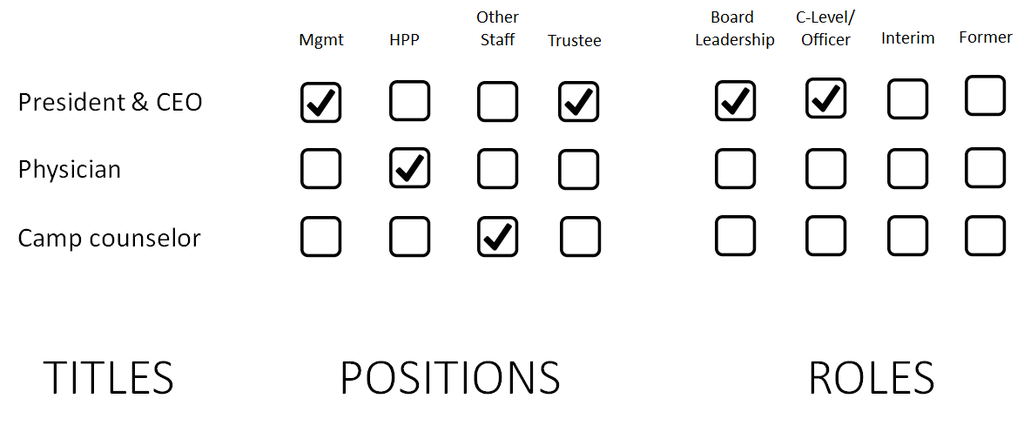

Example of Positions and Roles Assignment

4 Positions:

- Management
- HPP
- Other Staff
- Trustee

4 Roles

- Board Leadership
- C-Level/Officer
- Interim
- Former

### Management

```r
d2$Mgmt <- 0

d2$Mgmt[ d2$CEO == 1 ] <- 1
d2$Mgmt[ d2$CFO == 1 ] <- 1
d2$Mgmt[ d2$DEP.CEO == 1 ] <- 1
d2$Mgmt[ d2$COO == 1 ] <- 1
d2$Mgmt[ d2$HUM.RES == 1 ] <- 1
d2$Mgmt[ d2$DEP.HEAD == 1 ] <- 1
d2$Mgmt[ d2$MAN == 1 ] <- 1
d2$Mgmt[ d2$DEV == 1 ] <- 1
d2$Mgmt[ d2$TECH == 1 ] <- 1
d2$Mgmt[ d2$COMM == 1 ] <- 1
d2$Mgmt[ d2$MED.MAN == 1 ] <- 1
d2$Mgmt[ d2$ACADEMIC.MAN == 1 ] <- 1
```

### HPP

```r
d2$HPP <- 0

d2$HPP[ d2$PROFESIONAL == 1 ] <- 1
d2$HPP[ d2$LEGAL == 1 ] <- 1
d2$HPP[ d2$PROJECT == 1 ] <- 1
d2$HPP[ d2$TRAIN == 1 ] <- 1
```

### Other Staff

```r
d2$Other.Staff <- 0

d2$Other.Staff[ d2$HPP == 0 & d2$Mgmt == 0 & d2$TRUST == 0] <- 1
```

### Trustee

```r
d2$Trustee <- 0
```

### Board Leadership

```r
d2$Board.Leadership <- 0

d2$Board.Leadership[ d2$CEO == 1 & d2$TRUST == 1 ] <- 1
d2$Board.Leadership[ d2$COO == 1 & d2$TRUST == 1 ] <- 1
d2$Board.Leadership[ d2$CFO == 1 & d2$TRUST == 1 ] <- 1
d2$Board.Leadership[ d2$Treasurer == 1 & d2$TRUST == 1 ] <- 1
d2$Board.Leadership[ d2$DEP.CEO == 1 & d2$TRUST == 1 ] <- 1
d2$Board.Leadership[ d2$SEC == 1 & d2$TRUST == 1 ] <- 1
d2$Board.Leadership[ d2$Officer == 1 & d2$TRUST == 1 ] <- 1
```

### C-Level / Officer

```r
d2$C.Level <- 0

d2$C.Level [ grepl( " C[A-Z]O ", d2$TitleTxt2) ] <- 1
d2$C.Level [ grepl( " CHIEF ", d2$TitleTxt2) ] <- 1
d2$C.Level [ d2$Officer == 1 ] <- 1
```

### Interim

```r
d2$Interim <- 0

d2$Interim [ grepl( "SINCE", toupper(d2$TitleTxt) ) ] <- 1
d2$Interim [ grepl( "FROM", toupper(d2$TitleTxt) ) ] <- 1
d2$Interim [ grepl( "INTERIM", toupper(d2$TitleTxt) ) ] <- 1
d2$Interim [ grepl( "TEMP", toupper(d2$TitleTxt) ) ] <- 1
d2$Interim [ grepl( "TEMPORARY", toupper(d2$TitleTxt) ) ] <- 1
```

### Former

```r
d2$Former <- 0
d2$Former [ grepl( "FORMER", toupper(d2$TitleTxt) ) ] <- 1
d2$Former [ grepl( "THRU", toupper(d2$TitleTxt) ) ] <- 1
d2$Former [ grepl( "THROUGH", toupper(d2$TitleTxt) ) ] <- 1
d2$Former [ grepl( "PAST", toupper(d2$TitleTxt) ) ] <- 1
d2$Former [ d2$FmrOfficer == 1 ] <- 1
```

## Roles and Positions Descriptive Statistics

```r
n<-nrow(d2)
RnP.Desc <- matrix(2,2,2) %>% as.data.frame()

RnP.Desc[1,] <- c(sum(d2$Mgmt), sum(d2$Mgmt)/n)
RnP.Desc[2,] <- c(sum(d2$HPP), sum(d2$HPP)/n)
RnP.Desc[3,] <- c(sum(d2$Other.Staff), sum(d2$Other.Staff)/n)
RnP.Desc[4,] <- c(sum(d2$Board.Leadership), sum(d2$Board.Leadership)/n)
RnP.Desc[5,] <- c(sum(d2$C.Level), sum(d2$C.Level)/n)
RnP.Desc[6,] <- c(sum(d2$Interim), sum(d2$Interim)/n)
RnP.Desc[7,] <- c(sum(d2$Former), sum(d2$Former)/n)

Cats <-c("Mgmt", "HPP", "Other Staff","Board Leadership", "C-Level", "Interim", "Former")
RnP.Desc<-cbind(Cats, RnP.Desc)
colnames(RnP.Desc) <- c("Roles and Positions", "Total", "Percentage of obs")
RnP.Desc %>% pander()
```

| Roles and Positions | Total | Percentage of obs |
| --- | --- | --- |
| Mgmt | 628339 | 0.6643 |
| HPP | 107590 | 0.1137 |
| Other Staff | 163768 | 0.1731 |
| Board Leadership | 132800 | 0.1404 |
| C-Level | 551996 | 0.5836 |
| Interim | 5321 | 0.005625 |
| Former | 24393 | 0.02579 |

```r
saveRDS( d2, "Data/categorized-titles.rds")
```